# Comoto Time Series

Malia Crane

8/23/2021

### Section A - Customer Orders

```r
#Import Data, classify column data types
data <- read.csv("C:/Users/cran5028/Downloads/ComotoCrane-main/ecom_data.csv", row.names=NULL, stringsAsFactors=TRUE)
data$CustomerID<-as.factor(data$CustomerID)
data$InvoiceDay<-as.Date(data$InvoiceDay)
data$InvoiceDay<-as.POSIXct(data$InvoiceDay,format="%Y-%M-%D")
data$ID <- as.character(seq.int(nrow(data)))

#Filter out identified issues with data, negative sales amounts and SKU outliers:
data%>%filter(Sales >0)->data
data[!(data$SKU=="C2" | data$SKU=="BANK CHARGES" | data$SKU=="CRUK" | data$SKU=="D" | data$SKU=="DOT" | data$SKU=="M" | data$SKU=="PADS" | data$SKU=="POST"),]->data
droplevels(data$SKU)
#Create first 90-day temporal group
data%>%
  filter(Sales>0 & InvoiceDay>="2010-11-30" &InvoiceDay<"2011-02-28" )%>%         group_by(CustomerID)%>% mutate(TGroup1=n_distinct(SalesOrder))->y
y<-as.data.frame(y)
left_join(x=data,y=y,by=c("SalesOrder", "SKU", "Description", "UnitPrice", "CustomerID", "Channel", "State", "InvoiceDay", "Sales", "Quantity", "ID"))->data

#Second Group
data%>%
  filter(Sales>0 & InvoiceDay>="2011-02-28" &InvoiceDay<"2011-05-29" )%>%         group_by(CustomerID)%>% mutate(TGroup2=n_distinct(SalesOrder))->y
y<-as.data.frame(y)
left_join(x=data,y=y,by=c("SalesOrder", "SKU", "Description", "UnitPrice", "CustomerID", "Channel", "State", "InvoiceDay", "Sales", "Quantity", "ID","TGroup1"))->data
#Third Group
data%>%
  filter(Sales>0 & InvoiceDay>="2011-05-29" &InvoiceDay<"2011-08-27" )%>%         group_by(CustomerID)%>% mutate(TGroup3=n_distinct(SalesOrder))->y
y<-as.data.frame(y)
left_join(x=data,y=y,by=c("SalesOrder", "SKU", "Description", "UnitPrice", "CustomerID", "Channel", "State", "InvoiceDay", "Sales", "Quantity", "ID","TGroup1","TGroup2"))->data
#Fourth Group
data%>%
  filter(Sales>0 & InvoiceDay>="2011-08-27" &InvoiceDay<"2011-11-25" )%>%         group_by(CustomerID)%>% mutate(TGroup4=n_distinct(SalesOrder))->y
y<-as.data.frame(y)
left_join(x=data,y=y,by=c("SalesOrder", "SKU", "Description", "UnitPrice", "CustomerID", "Channel", "State", "InvoiceDay", "Sales", "Quantity", "ID","TGroup1","TGroup2","TGroup3"))->data

#Fifth Group -
  #Or, How I'd setup the pipeline to pull from the last 90 days.
  #Since 2011 is much more than 90 days from 2021, instead of a today() datetime I use the last date in the dataset with max(), pretending that today is the last date captured in the data and making the script estimate 90 days from the end of any imported data that I'd pass through it.

a<-as.POSIXlt(max(data$InvoiceDay))
a$mday<-a$mday-90
#Create TSGroup 5
data%>%
  filter(Sales>0 & InvoiceDay>=a)%>%
  group_by(CustomerID)%>% mutate(TGroup5=n_distinct(SalesOrder))->y
y<-as.data.frame(y)
left_join(x=data,y=y,by=c("SalesOrder", "SKU", "Description", "UnitPrice", "CustomerID", "Channel", "State", "InvoiceDay", "Sales", "Quantity", "ID","TGroup1","TGroup2","TGroup3","TGroup4"))->data
a<-NULL
```

### Summary

1. Starting with fresh data, I’ve removed entries which include refunds or fees paid by selecting out negative sales amounts and unusual SKU’s.
2. Each of the Tgroups brought into ‘data’ represent the number of purchases made, by grouping on CustomerID and counting the number of distinct SalesOrders.
1. The fifth group is purely a demonstration to approach the ‘rolling 90 day window’ question, and could be used to automatically create the past 90 days of purchases, but is not used in the forecast.

[output not shown]

```r
#Omit %>%head() to see them all
data%>%group_by(CustomerID)%>%select(CustomerID,TGroup1,TGroup2,TGroup3,TGroup4,TGroup5)%>%head()
```

```
## # A tibble: 6 x 6
## # Groups:   CustomerID [6]
##   CustomerID TGroup1 TGroup2 TGroup3 TGroup4 TGroup5
##   <fct>        <int>   <int>   <int>   <int>   <int>
## 1 16746           NA      NA      NA      NA       6
## 2 17757           NA      NA      NA      NA      10
## 3 16764           NA      NA      NA       8       9
## 4 14346            1      NA      NA      NA      NA
## 5 16361           NA      NA      NA       3       4
## 6 17126           NA      NA       3      NA      NA
```

### Create time series

```r
#Creating the time series here as requested, including Channel data as a measure.
data%>%
  filter(Sales>0)%>%
  select(InvoiceDay,Channel,Sales)%>%
  arrange(Channel,InvoiceDay,Sales)%>%
  mutate(month=month(InvoiceDay),year=year(InvoiceDay))%>%
  group_by(year,month,Channel)%>%
  summarise(SumSales=sum(Sales))%>%
  arrange(year,month,SumSales)->tsdata

#Making a better looking date column for visuals.
tsdata$tsunit<-paste(paste(tsdata$year,"-"),tsdata$month)
tsdata[,c(ncol(tsdata),1:(ncol(tsdata)-1))]->tsdata
tsdata$year<-NULL
tsdata$month<-NULL
tsdata%>%arrange(Channel,tsunit)->tsdata

tsdata%>%
mutate(Month=yearmonth(tsunit))%>%
as_tsibble(index=Month,key=Channel)->tsdata

#Remove extraneous column
tsdata$tsunit<-NULL
```

### Section C - Forecasting

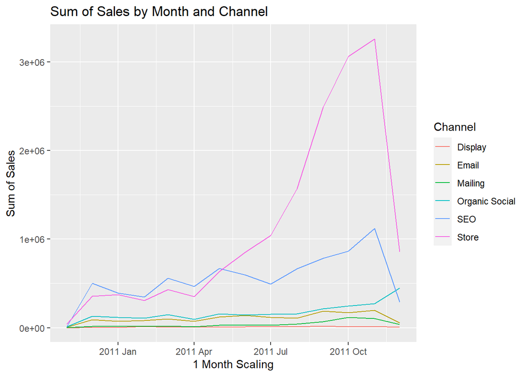

```r
#Begin decomposing and exploring options, saving good stuff here.

#Sanity Check, plot temporal series along SumSales by Channel.

autoplot(tsdata,SumSales)+labs(title="Sum of Sales by Month and Channel",y="Sum of Sales",x="1 Month Scaling")
```

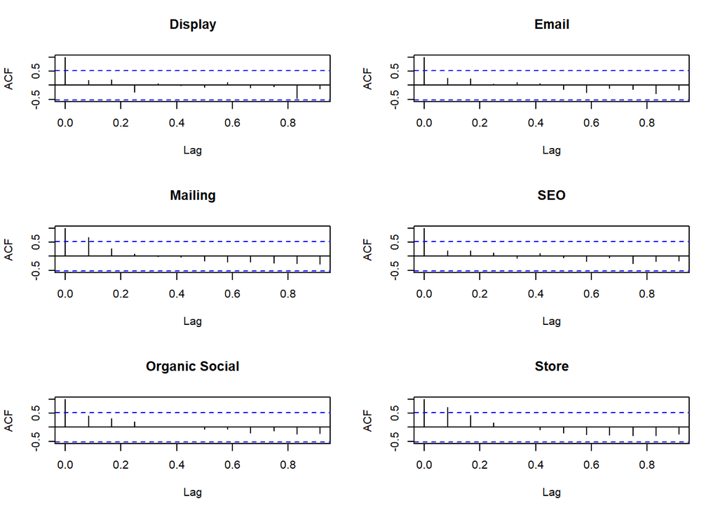

```r
#I can see initially here that Store and SEO are going to need to be modeled differently, their trends are clearly different from other channels.
tsdata%>%filter(Channel=="Store")->Sdata
tsdata%>%filter(!Channel=="Store")->tsdata
tsdata%>%filter(Channel=="SEO")->SEOdata
tsdata%>%filter(!Channel=="SEO")->tsdata

#Also separating out Organic Social due to reasons detailed later on
tsdata%>%filter(Channel=="Organic Social")->OSdata
tsdata%>%filter(!Channel=="Organic Social")->tsdata


#The first thing to consider is the stationarity of the time series, examined by autocorrelations.
#Single plots are made as such
par(mfrow=c(3,2))
acf(tsdata[tsdata$Channel=="Display",])
acf(tsdata[tsdata$Channel=="Email",])
acf(tsdata[tsdata$Channel=="Mailing",])
acf(SEOdata)
acf(OSdata)
acf(Sdata)
```

```r
par(mfrow=c(1,1))
#Store and Mailing have ACF plots which take two lags to reach autocorrelations below threshold, but with the KPSS test below it does not appear to be a substantial enough deviation to account for.

#Since this is unclear, I'll use the Kwiatkowski-Phillips-Schmidt-Shin (KPSS) test instead.
#Email, Display, Mailing Channels
tsdata%>%
features(SumSales,unitroot_kpss)
```

```
## # A tibble: 3 x 3
##   Channel kpss_stat kpss_pvalue
##   <fct>       <dbl>       <dbl>
## 1 Display     0.354      0.0970
## 2 Email       0.421      0.0683
## 3 Mailing     0.423      0.0674
```

```r
#Store Channel
Sdata%>%
features(SumSales,unitroot_kpss)
```

```
## # A tibble: 1 x 3
##   Channel kpss_stat kpss_pvalue
##   <fct>       <dbl>       <dbl>
## 1 Store       0.433      0.0631
```

```r
#SEO Channel
SEOdata%>%
     features(SumSales,unitroot_kpss)
```

```
## # A tibble: 1 x 3
##   Channel kpss_stat kpss_pvalue
##   <fct>       <dbl>       <dbl>
## 1 SEO         0.438      0.0608
```

```r
#Organic Social Channel
OSdata%>%
features(SumSales,unitroot_kpss)
```

```
## # A tibble: 1 x 3
##   Channel        kpss_stat kpss_pvalue
##   <fct>              <dbl>       <dbl>
## 1 Organic Social     0.545      0.0316
```

```r
#Results indicate all but organic Social are stationary series, good for forecasting with.

#Let's see what needs to be done to reach stationarity for Organic Social
OSdata%>%
     features(SumSales,unitroot_ndiffs)
```

```
## # A tibble: 1 x 2
##   Channel        ndiffs
##   <fct>           <int>
## 1 Organic Social      1
```

```r
#Indicates a difference of 1 for Organic Social is all that's needed.

OSdata%>%
  mutate(diff_SumSales=difference(SumSales))->OSdata
#Differenced time points for this channel mean that this channel's forecasts are now representing changes from the last month, rather than representing total sales amounts.
OSdata%>%
    features(diff_SumSales,unitroot_kpss)
```

```
## # A tibble: 1 x 3
##   Channel        kpss_stat kpss_pvalue
##   <fct>              <dbl>       <dbl>
## 1 Organic Social     0.255         0.1
```

```r
#We now have stationarity.
 #Clean up data
OSdata$SumSales<-NULL
na.omit(OSdata)->OSdata

#The differencing of just one unit results in a situation where I have to either impute the missing value or keep the models separate due to them now existing on different temporal frames.
#I'm going to go with keeping them separate and avoid unnecessary assumptions, as I've done with Store Channel
#Cleanup old factor levels
droplevels(tsdata)->tsdata
```

### Forecasting Summary

1. At the outset, it’s immediately clear with Store and SEO have far higher variance and range than others, and are radically different trends than the other channels, so they are separated out early to be analyzed differently.
2. Every channel but Organic Social were stationary time series at the outset, so only Organic Social is differenced. The differencing process changes the number of time units available, as well as the type of model in action ‘under the hood’- so this channel is also separated out.

### Decomposition

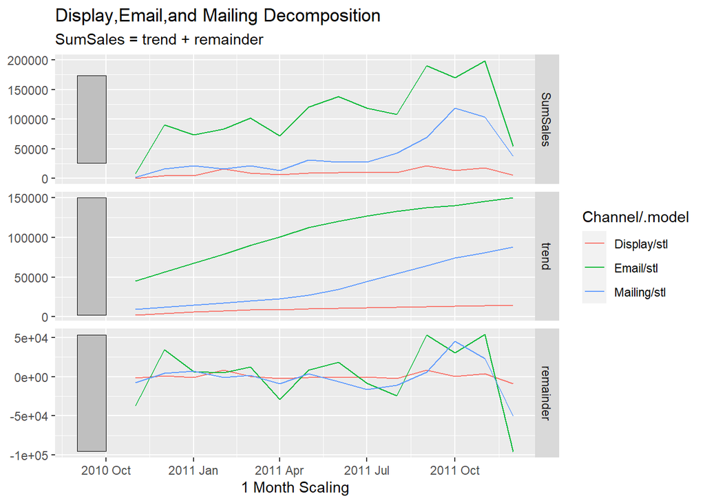

```r
############
#At this stage, Sdata holds Store, OSdata holds Organic Social, and tsdata holds all other channels
############
#Beginning Decomposition
tsdata%>%model(stl=STL(SumSales))%>%
  components(tsdata)%>%
  autoplot(SumSales)->tsdcmp
tsdcmp+labs(title="Display,Email,and Mailing Decomposition",x="1 Month Scaling")
```

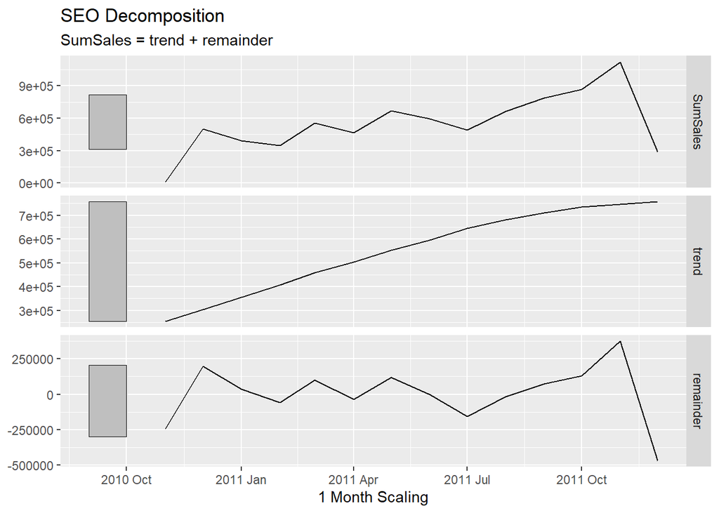

```r
#Email,Display, and Mailing are consistent over time with higher sales increases for Mailing over Display, and Email over both. Another notable drop at the end of the series as seen for each channel.

SEOdata%>%model(stl=STL(SumSales))%>%
  components(SEOdata)%>%
  autoplot(SumSales)->SEOdcmp
SEOdcmp+labs(title="SEO Decomposition",x="1 Month Scaling")
```

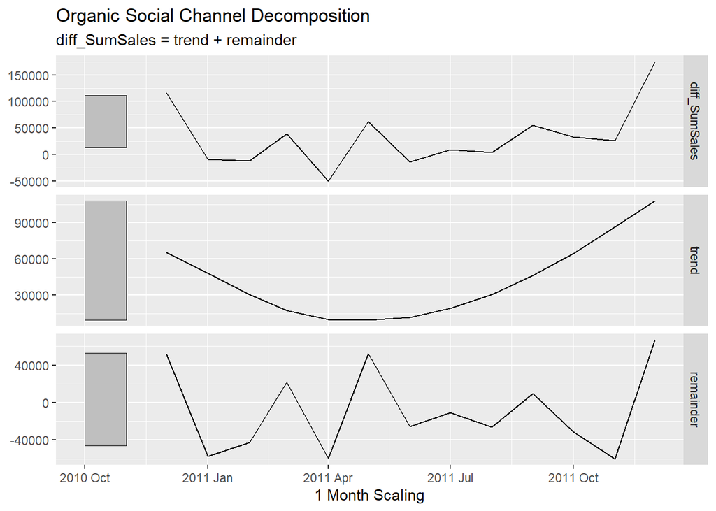

```r
#SEO has a generallly consistent increase in sales over time, again with a drop at the end of the period.

OSdata%>%model(stl=STL(diff_SumSales))%>%
     components(OSdata)%>%
     autoplot(diff_SumSales)->OSdcmp
OSdcmp+labs(title="Organic Social Channel Decomposition",x="1 Month Scaling")
```

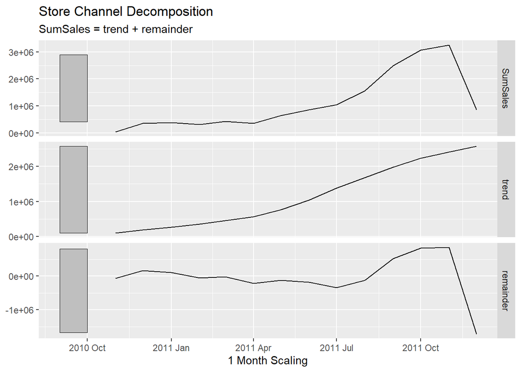

```r
#Trend is curvilinear over the period, but I wouldn't expect that to be a continuing trend of sinusoidal activity in the long run. This kind of nonlinearity suggests a more difficult to model series than I have timepoints to evaluate, limiting the models which will be useful.

Sdata%>%model(stl=STL(SumSales))%>%
     components(Sdata)%>%
     autoplot(SumSales)->Sdcmp
Sdcmp+labs(title="Store Channel Decomposition",x="1 Month Scaling")
```

```r
#Store Channel Trend is increasing over time, with a sharp fall at the end of the series.
```